# Hitters Salary Analysis

Group E - Ege John Isik 302991 - Muhammet Emin Albayram 303991

07 Nisan, 2025

# 1 Introduction

This analysis examines the relationship between baseball player statistics and their salaries using the Hitters dataset. The dataset contains information on Major League Baseball players from the 1986 and 1987 seasons, including performance metrics, career statistics, and salary information.

```r
# Load the Hitters dataset
hitters <- read.csv("Hitters.csv")

# Display a clean summary table of the first few rows
knitr::kable(head(hitters),
             caption = "First 6 rows of the Hitters dataset",
             align = "c",
             booktabs = TRUE) %>%
  kableExtra::kable_styling(bootstrap_options = c("striped", "hover", "condensed"),
                          full_width = FALSE,
                          font_size = 11) %>%
  kableExtra::column_spec(column = 1, bold = TRUE)
```

First 6 rows of the Hitters dataset

| AtBat | Hits | HmRun | Runs | RBI | Walks | Years | CAtBat | CHits | CHmRun | CRuns | CRBI | CWalks | League | Division | PutOuts | Assists | Errors | Salary | NewLeague |
| --- | --- | --- | --- | --- | --- | --- | --- | --- | --- | --- | --- | --- | --- | --- | --- | --- | --- | --- | --- |
| 293 | 66 | 1 | 30 | 29 | 14 | 1 | 293 | 66 | 1 | 30 | 29 | 14 | A | E | 446 | 33 | 20 | NA | A |
| 315 | 81 | 7 | 24 | 38 | 39 | 14 | 3449 | 835 | 69 | 321 | 414 | 375 | N | W | 632 | 43 | 10 | 475.0 | N |
| 479 | 130 | 18 | 66 | 72 | 76 | 3 | 1624 | 457 | 63 | 224 | 266 | 263 | A | W | 880 | 82 | 14 | 480.0 | A |
| 496 | 141 | 20 | 65 | 78 | 37 | 11 | 5628 | 1575 | 225 | 828 | 838 | 354 | N | E | 200 | 11 | 3 | 500.0 | N |
| 321 | 87 | 10 | 39 | 42 | 30 | 2 | 396 | 101 | 12 | 48 | 46 | 33 | N | E | 805 | 40 | 4 | 91.5 | N |
| 594 | 169 | 4 | 74 | 51 | 35 | 11 | 4408 | 1133 | 19 | 501 | 336 | 194 | A | W | 282 | 421 | 25 | 750.0 | A |

# 2 Data Import and Pre-Processing

```r
# We already imported the data in the previous step
# Check dimensions and structure
dim(hitters)        # Total number of units and measurements
```

```
## [1] 317  20
```

```r
str(hitters)        # Shows data structure and types
```

```
## 'data.frame':    317 obs. of  20 variables:
##  $ AtBat    : int  293 315 479 496 321 594 185 298 323 574 ...
##  $ Hits     : int  66 81 130 141 87 169 37 73 81 159 ...
##  $ HmRun    : int  1 7 18 20 10 4 1 0 6 21 ...
##  $ Runs     : int  30 24 66 65 39 74 23 24 26 107 ...
##  $ RBI      : int  29 38 72 78 42 51 8 24 32 75 ...
##  $ Walks    : int  14 39 76 37 30 35 21 7 8 59 ...
##  $ Years    : int  1 14 3 11 2 11 2 3 2 10 ...
##  $ CAtBat   : int  293 3449 1624 5628 396 4408 214 509 341 4631 ...
##  $ CHits    : int  66 835 457 1575 101 1133 42 108 86 1300 ...
##  $ CHmRun   : int  1 69 63 225 12 19 1 0 6 90 ...
##  $ CRuns    : int  30 321 224 828 48 501 30 41 32 702 ...
##  $ CRBI     : int  29 414 266 838 46 336 9 37 34 504 ...
##  $ CWalks   : int  14 375 263 354 33 194 24 12 8 488 ...
##  $ League   : chr  "A" "N" "A" "N" ...
##  $ Division : chr  "E" "W" "W" "E" ...
##  $ PutOuts  : int  446 632 880 200 805 282 76 121 143 238 ...
##  $ Assists  : int  33 43 82 11 40 421 127 283 290 445 ...
##  $ Errors   : int  20 10 14 3 4 25 7 9 19 22 ...
##  $ Salary   : num  NA 475 480 500 91.5 ...
##  $ NewLeague: chr  "A" "N" "A" "N" ...
```

```
## ## Categorical Variables Summary
```

```
## ### League distribution:
```

| League | Count |
| --- | --- |
| A | 173 |
| N | 144 |

```
## ### Division distribution:
```

| Division | Count |
| --- | --- |
| E | 156 |
| W | 161 |

```
## ### New League distribution:
```

| New League | Count |
| --- | --- |
| A | 174 |
| N | 143 |

- **Batting performance metrics:** AtBat, Hits, HmRun, Runs, RBI
- **Career statistics:** Years, CAtBat, CHits, CHmRun, CRuns, CRBI, CWalks
- **Categorical variables:** League, Division, NewLeague
- **Target variable:** Salary (in thousands of dollars)

## 2.1 Missing Value Analysis

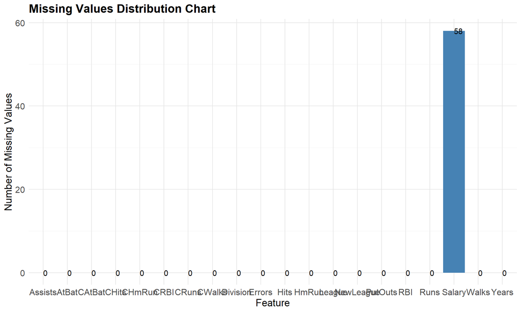

```r
# Create a standardized theme for all plots
my_theme <- theme_minimal() +
  theme(
    plot.title = element_text(size = 16, face = "bold"),
    plot.subtitle = element_text(size = 12, face = "italic"),
    axis.title = element_text(size = 14),
    axis.text = element_text(size = 12),
    legend.title = element_text(size = 14),
    legend.text = element_text(size = 12),
    panel.grid.major = element_line(color = "gray90"),
    panel.grid.minor = element_line(color = "gray95")
  )

# Check for missing values
missing_counts <- colSums(is.na(hitters))
missing_percentage <- round(missing_counts/nrow(hitters)*100, 2)

missing_df <- data.frame(
  Variable = names(missing_counts),
  Missing_Count = missing_counts,
  Missing_Percentage = missing_percentage
) %>% arrange(desc(Missing_Count))

# Visualize missing values pattern
missing_pattern <- hitters %>%
  is.na() %>%
  colSums() %>%
  sort(decreasing = TRUE)

ggplot(data.frame(feature = names(missing_pattern), missing_pct = missing_pattern), aes(x = missing_pct, y = feature)) +
  geom_bar(stat = "identity", fill = "steelblue") +
  geom_text(aes(label = paste0(round(missing_pct, 2))), hjust = 0) +
  labs(title = "Missing Values Distribution Chart", x = "Number of Missing Values", y = "Feature") +
  coord_flip() +
  my_theme
```

#### Missing Value Analysis Findings:

Since Salary is our target variable for prediction, imputing these missing values could introduce significant bias into our models. Given that we would still retain over 80% of the original data after removing these observations, a complete-case analysis is the most appropriate approach.

```r
# Count total rows before removing NAs
total_rows <- nrow(hitters)

# Remove rows with missing values
hitters_complete <- na.omit(hitters)

# Count rows after removal
complete_rows <- nrow(hitters_complete)
removed_count <- total_rows - complete_rows
removed_pct <- round(removed_count / total_rows * 100, 2)

# Create a summary dataframe
missing_summary <- data.frame(
  Metric = c("Original Observations", "Observations with Missing Values",
             "Complete Observations", "Percentage of Data Removed"),
  Value = c(total_rows, removed_count, complete_rows, paste0(removed_pct, "%"))
)

# Display as a nice table with bootstrap styling
knitr::kable(missing_summary,
             caption = "Missing Value Handling Summary",
             align = c("l", "c")) %>%
  kableExtra::kable_styling(bootstrap_options = c("striped", "hover"),
                           full_width = FALSE) %>%
  kableExtra::row_spec(0, bold = TRUE, background = "#E6E6FA") %>%
  kableExtra::column_spec(1, bold = TRUE)
```

Missing Value Handling Summary

| Metric | Value |
| --- | --- |
| Original Observations | 317 |
| Observations with Missing Values | 58 |
| Complete Observations | 259 |
| Percentage of Data Removed | 18.3% |

```r
# Use the dataset without missing values
hitters <- hitters_complete
```

## 2.2 Outlier Detection and Analysis

```r
# Create a function to identify outliers using IQR method
identify_outliers <- function(x, coef = 1.5) {
  q1 <- quantile(x, 0.25, na.rm = TRUE)
  q3 <- quantile(x, 0.75, na.rm = TRUE)
  iqr <- q3 - q1
  upper <- q3 + coef * iqr
  lower <- q1 - coef * iqr
  return(x < lower | x > upper)
}

# Apply to numeric columns
numeric_cols <- sapply(hitters, is.numeric)
outliers_check <- sapply(hitters[, numeric_cols], identify_outliers)
outliers_summary <- colSums(outliers_check)

# Create a better formatted outlier summary table
outlier_df <- data.frame(
  Variable = names(outliers_summary),
  Outlier_Count = outliers_summary,
  Percentage = round(outliers_summary/nrow(hitters)*100, 2)
) %>% arrange(desc(Outlier_Count))

# Display outlier summary as a nice table
knitr::kable(outlier_df,
             col.names = c("Variable", "Number of Outliers", "Percentage of Data (%)"),
             caption = "Outlier Summary by Variable",
             align = "c") %>%
  kableExtra::kable_styling(bootstrap_options = c("striped", "hover"),
                           full_width = FALSE) %>%
  kableExtra::row_spec(which(outlier_df$Outlier_Count > 15), background = "#FFE4E1")
```

Outlier Summary by Variable

|  | Variable | Number of Outliers | Percentage of Data (%) |
| --- | --- | --- | --- |
| PutOuts | PutOuts | 29 | 11.20 |
| CRBI | CRBI | 23 | 8.88 |
| CHmRun | CHmRun | 22 | 8.49 |
| CWalks | CWalks | 20 | 7.72 |
| Salary | Salary | 11 | 4.25 |
| CRuns | CRuns | 9 | 3.47 |
| CAtBat | CAtBat | 6 | 2.32 |
| CHits | CHits | 6 | 2.32 |
| Years | Years | 3 | 1.16 |
| Errors | Errors | 2 | 0.77 |
| HmRun | HmRun | 1 | 0.39 |
| Assists | Assists | 1 | 0.39 |
| AtBat | AtBat | 0 | 0.00 |
| Hits | Hits | 0 | 0.00 |
| Runs | Runs | 0 | 0.00 |
| RBI | RBI | 0 | 0.00 |
| Walks | Walks | 0 | 0.00 |

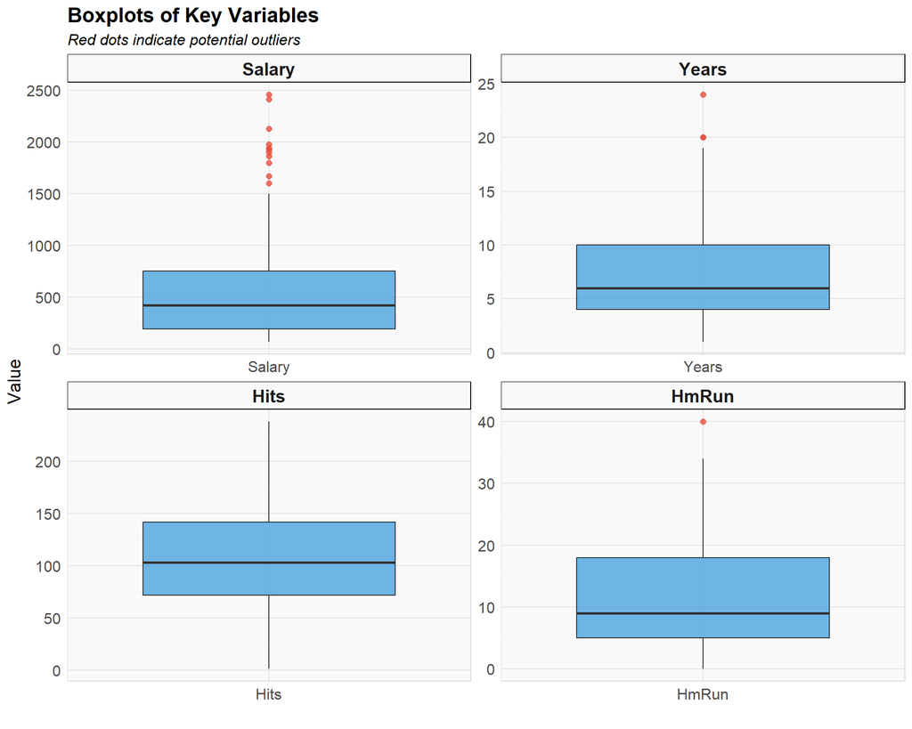

```r
# Visualize outliers in key variables with enhanced boxplots
key_vars <- c("Salary", "Years", "Hits", "HmRun")
key_data <- reshape2::melt(hitters[, key_vars])

# Create a more visually appealing boxplot with improved formatting
ggplot(key_data, aes(x = variable, y = value)) +
  geom_boxplot(fill = "#3498db", alpha = 0.7, outlier.color = "#e74c3c",
               outlier.shape = 16, outlier.size = 2, outlier.alpha = 0.8) +
  facet_wrap(~variable, scales = "free") +
  labs(title = "Boxplots of Key Variables",
       subtitle = "Red dots indicate potential outliers",
       x = "",
       y = "Value") +
  my_theme +
  theme(strip.text = element_text(size = 14, face = "bold"),
        strip.background = element_rect(fill = "#f9f9f9"),
        panel.background = element_rect(fill = "#f9f9f9", color = NA),
        panel.border = element_rect(color = "#dcdcdc", fill = NA))
```

#### Decision on Outliers:

We will retain these outliers in our analysis for several important reasons:

- They represent legitimate extreme values rather than data errors
- In sports analytics, outliers often contain valuable information about exceptional performers
- Removing outliers could eliminate important patterns that drive salary differences
- The models we plan to use should be robust enough to handle these legitimate extreme values

## 2.3 Exploratory Data Analysis

```r
# Create a more informative summary statistics table
num_stats <- psych::describe(select_if(hitters, is.numeric))
num_summary <- data.frame(
  Variable = rownames(num_stats),
  n = num_stats$n,
  mean = num_stats$mean,
  sd = num_stats$sd,
  median = num_stats$median,
  min = num_stats$min,
  max = num_stats$max,
  skew = num_stats$skew,
  kurtosis = num_stats$kurtosis
)

# Round only the numeric columns
num_summary[,2:9] <- round(num_summary[,2:9], digits = 2)

# Display the summary as a nicely formatted table with DT for better interactivity
DT::datatable(num_summary,
              caption = "Detailed Summary Statistics of Numeric Variables",
              options = list(
                pageLength = 10,
                dom = 'Bfrtip',
                scrollX = TRUE,
                autoWidth = TRUE
              ),
              rownames = FALSE,
              class = 'cell-border stripe') %>%
  DT::formatStyle(columns = 1, fontWeight = 'bold') %>%
  DT::formatRound(columns = 3:9, digits = 2)
```

| Variable | n | mean | sd | median | min | max | skew | kurtosis |
| --- | --- | --- | --- | --- | --- | --- | --- | --- |
| AtBat | 259 | 403.83 | 147.09 | 413 | 19 | 687 | -0.13 | -0.99 |
| Hits | 259 | 107.92 | 45.12 | 103 | 1 | 238 | 0.25 | -0.57 |
| HmRun | 259 | 11.58 | 8.8 | 9 | 0 | 40 | 0.8 | -0.22 |
| Runs | 259 | 54.72 | 25.51 | 52 | 0 | 130 | 0.36 | -0.6 |
| RBI | 259 | 51.31 | 25.83 | 47 | 0 | 121 | 0.57 | -0.41 |
| Walks | 259 | 40.77 | 21.39 | 37 | 0 | 105 | 0.54 | -0.39 |
| Years | 259 | 7.27 | 4.8 | 6 | 1 | 24 | 0.82 | -0.06 |
| CAtBat | 259 | 2645.37 | 2290.13 | 1928 | 19 | 14053 | 1.32 | 1.99 |
| CHits | 259 | 719.41 | 649.92 | 510 | 4 | 4256 | 1.46 | 2.93 |
| CHmRun | 259 | 68.3 | 81.76 | 39 | 0 | 548 | 2.23 | 6.15 |

[output cut: 7 more lines]

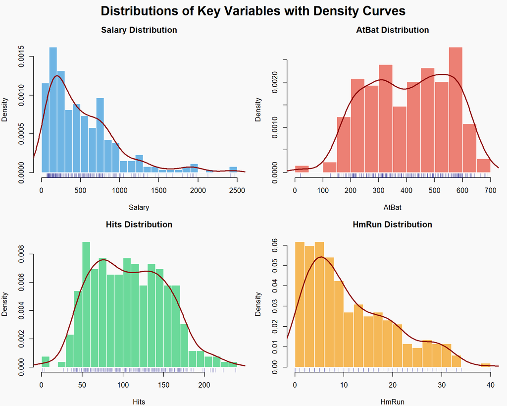

```r
# Enhanced histograms with density plots for key variables
key_vars <- c("Salary", "AtBat", "Hits", "HmRun")
par(mfrow = c(2, 2), mar = c(4, 4, 3, 1), oma = c(0, 0, 2, 0), bg = "#f9f9f9")

colors <- c("#3498db", "#e74c3c", "#2ecc71", "#f39c12")
i <- 1

for (var in key_vars) {
  hist(hitters[[var]],
       main = paste(var, "Distribution"),
       col = adjustcolor(colors[i], alpha.f = 0.7),
       border = "white",
       breaks = 20,
       probability = TRUE,
       xlab = var,
       font.main = 2)
  lines(density(hitters[[var]]), col = "darkred", lwd = 2)
  rug(hitters[[var]], col = adjustcolor("navy", alpha.f = 0.5))
  i <- i + 1
}
mtext("Distributions of Key Variables with Density Curves", outer = TRUE, cex = 1.5, font = 2)
```

#### Key Findings from Exploratory Analysis:

- Linear models may need transformation of the salary variable
- Feature selection will be important due to multicollinearity among predictors
- Years of experience is an important factor that influences many other variables

## 2.4 Data Transformation

```r
# Identify numeric columns (explicitly excluding the target variable "Salary")
predictors <- names(hitters)[sapply(hitters, is.numeric) & names(hitters) != "Salary"]

# Create a copy of the dataset
hitters_scaled <- hitters

# Standardize the numeric predictors
hitters_scaled[predictors] <- scale(hitters[predictors])

# Create a before/after comparison table for a few key variables
set.seed(123) # For reproducible sampling
sample_players <- sample(1:nrow(hitters), 5)

comparison_data <- data.frame(
  Player = 1:5,
  AtBat_Original = hitters[sample_players, "AtBat"],
  AtBat_Scaled = hitters_scaled[sample_players, "AtBat"],
  Hits_Original = hitters[sample_players, "Hits"],
  Hits_Scaled = hitters_scaled[sample_players, "Hits"],
  HmRun_Original = hitters[sample_players, "HmRun"],
  HmRun_Scaled = hitters_scaled[sample_players, "HmRun"]
)

# Display comparison table with improved formatting
knitr::kable(comparison_data,
             caption = "Comparison of Original vs. Standardized Values for 5 Random Players",
             align = "c",
             digits = 2) %>%
  kableExtra::kable_styling(bootstrap_options = c("striped", "hover"),
                           full_width = FALSE) %>%
  kableExtra::add_header_above(c(" " = 1, "At Bats" = 2, "Hits" = 2, "Home Runs" = 2)) %>%
  kableExtra::column_spec(1, bold = TRUE, background = "#f9f9f9") %>%
  kableExtra::column_spec(c(3,5,7), background = "#e8f4f8")
```

Comparison of Original vs. Standardized Values for 5 Random Players

| Player | At Bats AtBat_Original | At Bats AtBat_Scaled | Hits Hits_Original | Hits Hits_Scaled | Home Runs HmRun_Original | Home Runs HmRun_Scaled |
| --- | --- | --- | --- | --- | --- | --- |
| 1 | 514 | 0.75 | 144 | 0.80 | 0 | -1.32 |
| 2 | 568 | 1.12 | 158 | 1.11 | 20 | 0.96 |
| 3 | 341 | -0.43 | 110 | 0.05 | 9 | -0.29 |
| 4 | 374 | -0.20 | 94 | -0.31 | 5 | -0.75 |
| 5 | 512 | 0.74 | 131 | 0.51 | 26 | 1.64 |

```r
# Check standardization results
scaled_summary <- data.frame(
  Variable = predictors,
  Mean = sapply(hitters_scaled[predictors], mean),
  SD = sapply(hitters_scaled[predictors], sd)
)

# Round only the numeric columns
scaled_summary[,2:3] <- round(scaled_summary[,2:3], digits = 5)

# Display standardization verification table
knitr::kable(scaled_summary,
             col.names = c("Variable", "Mean (should be ~0)", "Standard Deviation (should be 1)"),
             caption = "Verification of Standardization Results",
             align = "c") %>%
  kableExtra::kable_styling(bootstrap_options = c("striped", "hover"),
                           full_width = FALSE) %>%
  kableExtra::row_spec(0, bold = TRUE, background = "#f9f9f9") %>%
  kableExtra::column_spec(1, bold = TRUE)
```

Verification of Standardization Results

|  | Variable | Mean (should be ~0) | Standard Deviation (should be 1) |
| --- | --- | --- | --- |
| AtBat | AtBat | 0 | 1 |
| Hits | Hits | 0 | 1 |
| HmRun | HmRun | 0 | 1 |
| Runs | Runs | 0 | 1 |
| RBI | RBI | 0 | 1 |
| Walks | Walks | 0 | 1 |
| Years | Years | 0 | 1 |
| CAtBat | CAtBat | 0 | 1 |
| CHits | CHits | 0 | 1 |
| CHmRun | CHmRun | 0 | 1 |
| CRuns | CRuns | 0 | 1 |
| CRBI | CRBI | 0 | 1 |
| CWalks | CWalks | 0 | 1 |
| PutOuts | PutOuts | 0 | 1 |
| Assists | Assists | 0 | 1 |
| Errors | Errors | 0 | 1 |

### Explanation of Preprocessing Choices

1. **Missing Values:** We removed rows with missing values rather than imputing them because:
   - The missing values only appear in the Salary column, which is our target variable
   - Imputing salary values might introduce bias in our prediction models
   - We still retain 82% of the dataset after removal, which is sufficient for our analysis
2. **Standardization:** We standardized the numeric predictors because:
   - Variables have different scales (e.g., AtBat vs HmRun) which can affect models like regression or k-nearest neighbors
   - Standardization gives all predictors equal importance initially
   - This helps with convergence in many machine learning algorithms
   - We explicitly excluded the Salary variable from standardization as it’s our target variable
3. **Exploratory Analysis:** We performed detailed exploration to:
   - Understand the distributions of key variables
   - Identify potential outliers or skewed distributions
   - Get a sense of the dataset’s characteristics before modeling
4. **Outlier Handling:** We decided to keep outliers because:
   - In sports data, outliers often represent exceptional players
   - Removing them would eliminate important information about high performers
   - The outliers appear legitimate and not due to data errors

The cleaned and standardized dataset (hitters_scaled) is now ready for further analysis and modeling.

# 3 Creating the Categorical Response Variable

Now we’ll convert the quantitative Salary variable into a categorical variable with three tiers.

```r
# Display the summary of Salary to understand its distribution
summary(hitters$Salary)
```

```
##    Min. 1st Qu.  Median    Mean 3rd Qu.    Max.
##    67.5   190.0   420.0   532.8   750.0  2460.0
```

```r
# Calculate tertiles
tertiles <- quantile(hitters$Salary, probs = c(0, 1/3, 2/3, 1), na.rm = TRUE)
tertiles
```

```
##        0% 33.33333% 66.66667%      100%
##      67.5     250.0     630.0    2460.0
```

```r
# Create SalaryLevel using salary tertiles
hitters$SalaryLevel <- cut(hitters$Salary,
                          breaks = tertiles,
                          labels = c("LowSalary", "MediumSalary", "HighSalary"),
                          include.lowest = TRUE)

# Verify the new variable
table(hitters$SalaryLevel)
```

```
##
##    LowSalary MediumSalary   HighSalary
##           92           81           86
```

```r
prop.table(table(hitters$SalaryLevel)) * 100  # Percentage in each category
```

```
##
##    LowSalary MediumSalary   HighSalary
##     35.52124     31.27413     33.20463
```

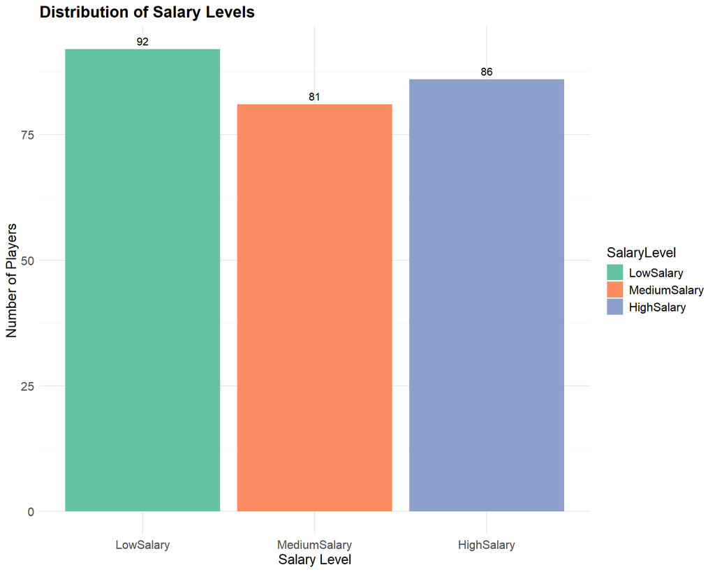

```r
# Visualize the distribution with improved styling
ggplot(hitters, aes(x = SalaryLevel, fill = SalaryLevel)) +
  geom_bar() +
  geom_text(stat = "count", aes(label = ..count..), vjust = -0.5) +
  scale_fill_manual(values = c("LowSalary" = "#66c2a5",
                               "MediumSalary" = "#fc8d62",
                               "HighSalary" = "#8da0cb")) +
  labs(title = "Distribution of Salary Levels",
       x = "Salary Level",
       y = "Number of Players") +
  my_theme
```

```r
# Also add SalaryLevel to our scaled dataset
hitters_scaled$SalaryLevel <- hitters$SalaryLevel
```

#### Explanation of Tertile Choice

I chose to use tertiles (dividing the data into three equal-sized groups) for the following reasons:

1. **Equal Group Sizes**: Using tertiles ensures we have approximately equal numbers of observations in each category, which is beneficial for classification models to avoid class imbalance problems.
2. **Domain Relevance**: The three categories (Low, Medium, High) provide a meaningful interpretation for baseball player salaries that aligns with common salary tier structures.
3. **Statistical Stability**: Having balanced categories helps with the stability of subsequent models and makes interpretation of model performance metrics more straightforward.
4. **Project Requirements**: Creating a categorical response variable with three levels follows the requirements of the assignment, allowing for multinomial logistic regression analysis.

## 3.1 Domain-Specific Salary Benchmarks

While statistical tertiles ensure balanced categories, it’s also important to understand how our divisions compare to real-world MLB salary benchmarks. This helps contextualize our analysis in terms of actual salary distributions in professional baseball.

```r
# Define league-specific thresholds
mlb_avg <- median(hitters$Salary, na.rm = TRUE)
mlb_low <- quantile(hitters$Salary, 0.25)  # Bottom 25%
mlb_high <- quantile(hitters$Salary, 0.75) # Top 25%

# Compare with tertiles
cat("Tertiles:", tertiles, "\n",
    "MLB Benchmarks: Low =", mlb_low, "Avg =", mlb_avg, "High =", mlb_high)
```

```
## Tertiles: 67.5 250 630 2460
##  MLB Benchmarks: Low = 190 Avg = 420 High = 750
```

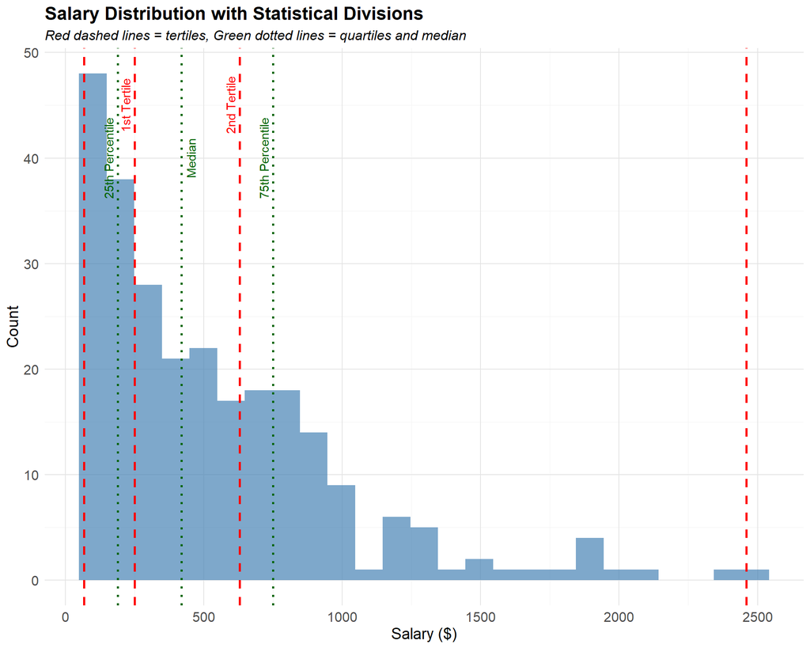

```r
# Create a more informative visualization
# Salary distribution with clear markings
ggplot(hitters, aes(x = Salary)) +
  geom_histogram(bins = 25, fill = "steelblue", alpha = 0.7) +
  geom_vline(xintercept = tertiles, color = "red", linetype = "dashed", size = 1) +
  geom_vline(xintercept = c(mlb_low, mlb_avg, mlb_high),
             color = "darkgreen", linetype = "dotted", size = 1) +
  annotate("text", x = tertiles[2], y = 45, label = "1st Tertile",
           color = "red", angle = 90, vjust = -0.5) +
  annotate("text", x = tertiles[3], y = 45, label = "2nd Tertile",
           color = "red", angle = 90, vjust = -0.5) +
  annotate("text", x = mlb_low, y = 40, label = "25th Percentile",
           color = "darkgreen", angle = 90, vjust = -0.5) +
  annotate("text", x = mlb_avg, y = 40, label = "Median",
           color = "darkgreen", angle = 90, vjust = 1.5) +
  annotate("text", x = mlb_high, y = 40, label = "75th Percentile",
           color = "darkgreen", angle = 90, vjust = -0.5) +
  labs(title = "Salary Distribution with Statistical Divisions",
       subtitle = "Red dashed lines = tertiles, Green dotted lines = quartiles and median",
       x = "Salary ($)",
       y = "Count") +
  my_theme
```

```r
# Compare category sizes
tertile_groups <- cut(hitters$Salary,
                     breaks = tertiles,
                     labels = c("Low", "Medium", "High"),
                     include.lowest = TRUE)

mlb_groups <- cut(hitters$Salary,
                 breaks = c(min(hitters$Salary), mlb_low, mlb_high, max(hitters$Salary)),
                 labels = c("Low", "Medium", "High"),
                 include.lowest = TRUE)

# Create a comparison table
category_comparison <- data.frame(
  Category = c("Low", "Medium", "High"),
  Tertile_Count = as.numeric(table(tertile_groups)),
  Tertile_Pct = round(prop.table(table(tertile_groups)) * 100, 1),
  MLB_Count = as.numeric(table(mlb_groups)),
  MLB_Pct = round(prop.table(table(mlb_groups)) * 100, 1)
)

# Display the comparison
cat("Category size comparison between tertiles and MLB benchmarks:\n")
```

```
## Category size comparison between tertiles and MLB benchmarks:
```

```r
print(category_comparison)
```

```
##   Category Tertile_Count Tertile_Pct.tertile_groups Tertile_Pct.Freq MLB_Count
## 1      Low            92                        Low             35.5        66
## 2   Medium            81                     Medium             31.3       134
## 3     High            86                       High             33.2        59
##   MLB_Pct.mlb_groups MLB_Pct.Freq
## 1                Low         25.5
## 2             Medium         51.7
## 3               High         22.8
```

#### Implications of Different Salary Divisions

The comparison between statistical tertiles and MLB benchmarks reveals important insights:

1. **Category Balance**: Our tertile approach creates equal-sized groups (as designed), whereas using MLB benchmarks would result in an uneven distribution with more players in the middle category.
2. **Real-World Context**: The MLB median salary provides a reference point that represents the middle of the actual salary distribution, rather than just a statistical division.
3. **Model Implications**: Using MLB benchmarks might better reflect real-world salary tiers, but could lead to class imbalance problems for our predictive models.
4. **Decision Justification**: We chose tertiles for our analysis to ensure statistical robustness, but the MLB benchmarks provide valuable context for interpreting our results in terms of actual salary structures in baseball.

This comparison helps bridge the gap between our statistical approach and the economic reality of MLB salary distributions.

# 4 Visual Data Inspection

Now, let’s explore the relationships between our newly created `SalaryLevel` and other predictors through visualizations. This will help identify which variables might be most useful in predicting salary levels.

## 4.1 Performance Metrics by Salary Level

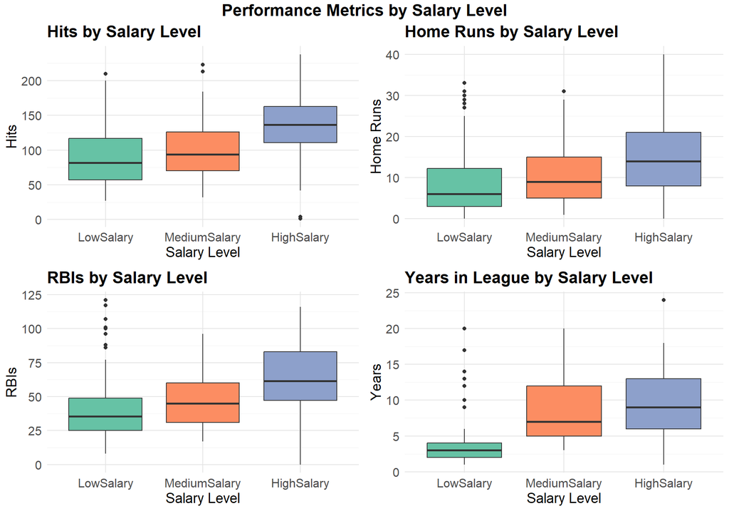

```r
# Create boxplots for key performance metrics with consistent styling
p1 <- ggplot(hitters, aes(x = SalaryLevel, y = Hits, fill = SalaryLevel)) +
  geom_boxplot() +
  scale_fill_manual(values = c("LowSalary" = "#66c2a5",
                              "MediumSalary" = "#fc8d62",
                              "HighSalary" = "#8da0cb")) +
  labs(title = "Hits by Salary Level", x = "Salary Level", y = "Hits") +
  my_theme +
  theme(legend.position = "none")

p2 <- ggplot(hitters, aes(x = SalaryLevel, y = HmRun, fill = SalaryLevel)) +
  geom_boxplot() +
  scale_fill_manual(values = c("LowSalary" = "#66c2a5",
                              "MediumSalary" = "#fc8d62",
                              "HighSalary" = "#8da0cb")) +
  labs(title = "Home Runs by Salary Level", x = "Salary Level", y = "Home Runs") +
  my_theme +
  theme(legend.position = "none")

p3 <- ggplot(hitters, aes(x = SalaryLevel, y = RBI, fill = SalaryLevel)) +
  geom_boxplot() +
  scale_fill_manual(values = c("LowSalary" = "#66c2a5",
                              "MediumSalary" = "#fc8d62",
                              "HighSalary" = "#8da0cb")) +
  labs(title = "RBIs by Salary Level", x = "Salary Level", y = "RBIs") +
  my_theme +
  theme(legend.position = "none")

p4 <- ggplot(hitters, aes(x = SalaryLevel, y = Years, fill = SalaryLevel)) +
  geom_boxplot() +
  scale_fill_manual(values = c("LowSalary" = "#66c2a5",
                              "MediumSalary" = "#fc8d62",
                              "HighSalary" = "#8da0cb")) +
  labs(title = "Years in League by Salary Level", x = "Salary Level", y = "Years") +
  my_theme +
  theme(legend.position = "none")

# Arrange the boxplots in a grid
grid.arrange(p1, p2, p3, p4, ncol = 2,
             top = textGrob("Performance Metrics by Salary Level",
                           gp = gpar(fontsize = 16, fontface = "bold")))
```

```r
# Create a data frame for the performance metrics table
performance_metrics <- data.frame(
  Metric = c("Hits", "Home Runs", "RBIs", "Experience (Years)"),
  Observation = c("Higher salaries correlate with more hits (clear increasing trend)",
                 "Higher-salaried players hit more home runs, with notable separation",
                 "Clear increasing trend with salary level, especially for high-salary players",
                 "Strong indicator of high salary, suggesting experience is highly valued")
)

cat('<div class="main-findings" style="max-width:90%;margin:15px auto;">')
```

```r
cat('<h4>Key Observations: Performance Metrics by Salary Level</h4>')
```

#### Key Observations: Performance Metrics by Salary Level

```r
knitr::kable(performance_metrics,
             col.names = c("Performance Metric", "Observation"),
             align = c("l", "l"),
             caption = NULL) %>%
  kableExtra::kable_styling(bootstrap_options = c("striped", "hover"),
                          full_width = FALSE,
                          position = "center",
                          font_size = 11) %>%
  kableExtra::column_spec(1, bold = TRUE, color = "#3498db") %>%
  kableExtra::row_spec(0, bold = TRUE, background = "#f2f2f2")
```

| Performance Metric | Observation |
| --- | --- |
| Hits | Higher salaries correlate with more hits (clear increasing trend) |
| Home Runs | Higher-salaried players hit more home runs, with notable separation |
| RBIs | Clear increasing trend with salary level, especially for high-salary players |
| Experience (Years) | Strong indicator of high salary, suggesting experience is highly valued |

```r
cat('<p><strong>Summary:</strong> All four performance metrics show a clear positive relationship with salary level, with years of experience and offensive production (especially RBIs) appearing to be the strongest indicators of higher salary.</p>')
```

**Summary:** All four performance metrics show a clear positive relationship with salary level, with years of experience and offensive production (especially RBIs) appearing to be the strongest indicators of higher salary.

```r
cat('</div>')
```

## 4.2 Career vs. Current Performance

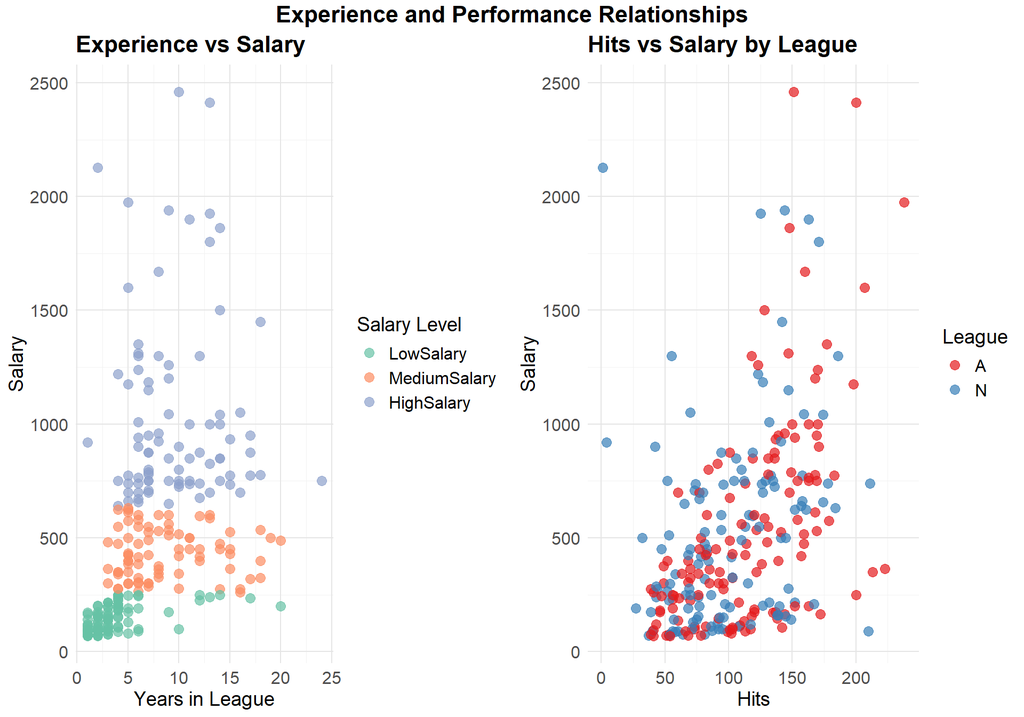

```r
# Years vs Salary colored by Salary Level
p5 <- ggplot(hitters, aes(x = Years, y = Salary, color = SalaryLevel)) +
  geom_point(alpha = 0.7, size = 3) +
  scale_color_manual(values = c("LowSalary" = "#66c2a5",
                               "MediumSalary" = "#fc8d62",
                               "HighSalary" = "#8da0cb")) +
  labs(title = "Experience vs Salary",
       x = "Years in League",
       y = "Salary",
       color = "Salary Level") +
  my_theme

# Hits vs Salary colored by League
p6 <- ggplot(hitters, aes(x = Hits, y = Salary, color = League)) +
  geom_point(alpha = 0.7, size = 3) +
  scale_color_manual(values = c("A" = "#e41a1c", "N" = "#377eb8")) +
  labs(title = "Hits vs Salary by League",
       x = "Hits",
       y = "Salary",
       color = "League") +
  my_theme

# Compare current season to career performance
p7 <- ggplot(hitters, aes(x = Hits, y = CHits/Years, color = SalaryLevel)) +
  geom_point(alpha = 0.7, size = 3) +
  scale_color_manual(values = c("LowSalary" = "#66c2a5",
                               "MediumSalary" = "#fc8d62",
                               "HighSalary" = "#8da0cb")) +
  geom_smooth(method = "lm", se = FALSE, color = "black", linetype = "dashed") +
  labs(title = "Current vs Average Career Hits",
       x = "Current Season Hits",
       y = "Career Average Hits per Season",
       color = "Salary Level") +
  my_theme

# Arrange scatter plots with interpretation
grid.arrange(p5, p6, ncol = 2,
             top = textGrob("Experience and Performance Relationships",
                           gp = gpar(fontsize = 16, fontface = "bold")))
```

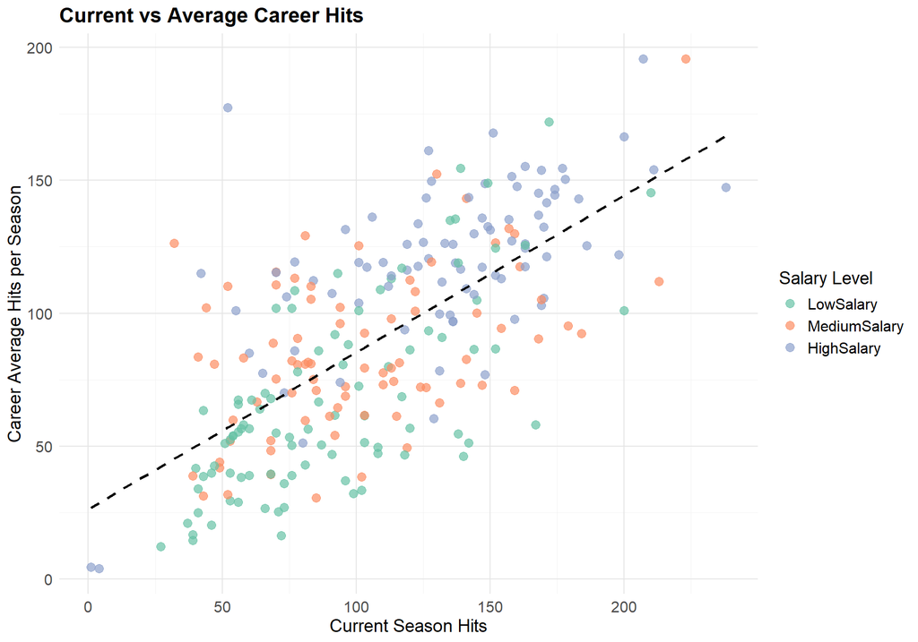

```r
# Display the third plot separately with additional annotation
p7
```

```r
# Create a data frame for the career vs current performance table
career_insights <- data.frame(
  Aspect = c("Experience", "League Comparison", "Career Consistency", "Performance Clusters"),
  Finding = c("Clear positive relationship between years in league and salary",
              "No significant salary differences between American and National League players with similar performance",
              "Players with higher career averages tend to earn more, even when current season performance is similar",
              "High-salary players cluster in the upper-right quadrant of performance metrics (both current and career)")
)

cat('<div class="main-findings" style="max-width:90%;margin:15px auto;">')
```

```r
cat('<h4>Career vs. Current Performance - Key Insights</h4>')
```

#### Career vs. Current Performance - Key Insights

```r
knitr::kable(career_insights,
             col.names = c("Key Aspect", "Finding"),
             align = c("l", "l")) %>%
  kableExtra::kable_styling(bootstrap_options = c("striped", "hover"),
                          full_width = FALSE,
                          position = "center",
                          font_size = 11) %>%
  kableExtra::column_spec(1, bold = TRUE, color = "#2c3e50", width = "15em") %>%
  kableExtra::row_spec(0, bold = TRUE, background = "#ebf5fb")
```

[output not shown]

```r
cat('<p><strong>Implications:</strong> Long-term career performance appears to be a more reliable predictor of salary than single-season metrics, suggesting MLB teams value consistency and experience when determining player compensation.</p>')
```

**Implications:** Long-term career performance appears to be a more reliable predictor of salary than single-season metrics, suggesting MLB teams value consistency and experience when determining player compensation.

```r
cat('</div>')
```

## 4.3 Performance Distribution Analysis

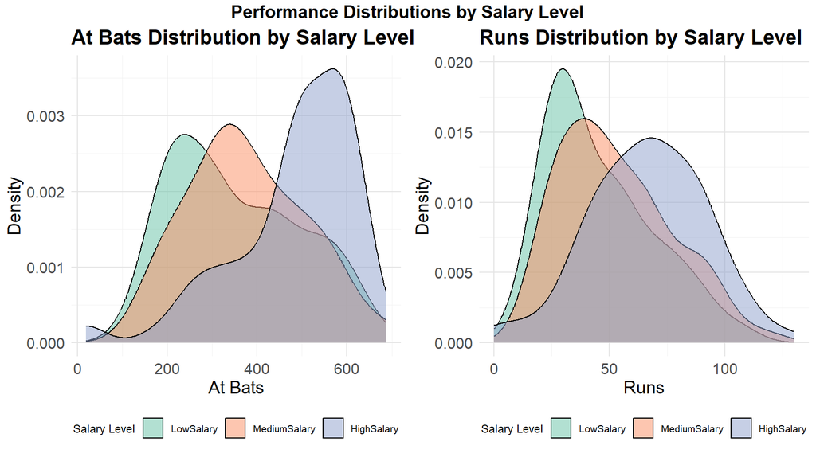

```r
# Density plots for key metrics by Salary Level with improved styling
p8 <- ggplot(hitters, aes(x = AtBat, fill = SalaryLevel)) +
  geom_density(alpha = 0.5) +
  scale_fill_manual(values = c("LowSalary" = "#66c2a5",
                              "MediumSalary" = "#fc8d62",
                              "HighSalary" = "#8da0cb")) +
  labs(title = "At Bats Distribution by Salary Level",
       x = "At Bats",
       y = "Density",
       fill = "Salary Level") +
  my_theme +
  theme(legend.position = "bottom",
        legend.box = "horizontal",
        legend.title = element_text(size=9),
        legend.text = element_text(size=8))

p9 <- ggplot(hitters, aes(x = Runs, fill = SalaryLevel)) +
  geom_density(alpha = 0.5) +
  scale_fill_manual(values = c("LowSalary" = "#66c2a5",
                              "MediumSalary" = "#fc8d62",
                              "HighSalary" = "#8da0cb")) +
  labs(title = "Runs Distribution by Salary Level",
       x = "Runs",
       y = "Density",
       fill = "Salary Level") +
  my_theme +
  theme(legend.position = "bottom",
        legend.box = "horizontal",
        legend.title = element_text(size=9),
        legend.text = element_text(size=8))

# Arrange density plots
grid.arrange(p8, p9, ncol = 2,
             top = textGrob("Performance Distributions by Salary Level",
                           gp = gpar(fontsize = 14, fontface = "bold")))
```

```r
# Create a nicer formatted table for distribution analysis
distribution_analysis <- data.frame(
  Metric = c("At Bats", "Runs", "Playing Time", "Production Value"),
  Observation = c("Higher-salaried players have more plate appearances (distribution shifts right with each salary tier)",
                 "Clear separation between salary tiers, with higher-salaried players scoring more runs",
                 "More at-bats suggests higher-paid players receive more regular playing time",
                 "Run production appears to be a key factor in salary determination")
)

cat('<div class="main-findings" style="max-width:90%;margin:15px auto;">')
```

```r
cat('<h4>Performance Distribution Analysis</h4>')
```

#### Performance Distribution Analysis

```r
knitr::kable(distribution_analysis,
             col.names = c("Aspect", "Key Observation"),
             align = c("l", "l")) %>%
  kableExtra::kable_styling(bootstrap_options = c("striped", "hover"),
                          full_width = FALSE,
                          position = "center",
                          font_size = 11) %>%
  kableExtra::column_spec(1, bold = TRUE, color = "#2c3e50") %>%
  kableExtra::row_spec(0, bold = TRUE, background = "#eafaf1") %>%
  kableExtra::row_spec(c(1,2), background = "#f2f2f2")
```

| Aspect | Key Observation |
| --- | --- |
| At Bats | Higher-salaried players have more plate appearances (distribution shifts right with each salary tier) |
| Runs | Clear separation between salary tiers, with higher-salaried players scoring more runs |
| Playing Time | More at-bats suggests higher-paid players receive more regular playing time |
| Production Value | Run production appears to be a key factor in salary determination |

```r
cat('<p><strong>Conclusion:</strong> The density plots provide strong evidence that playing time and offensive productivity are both significant factors in determining player salaries, with clear separation between salary tiers.</p>')
```

**Conclusion:** The density plots provide strong evidence that playing time and offensive productivity are both significant factors in determining player salaries, with clear separation between salary tiers.

```r
cat('</div>')
```